# Part II - Ford GoBike System Data Analysis

## by Omoniyi Akinpelumi

## Dataset Overview

> The modified dataset has 174952 observations and 18 features. Within this data are 4607 unique bikers and 329 unique bike station information to be analysed. These dataset also have a good mixture of strings, floats and int data types.

The main features of the dataset are the

- Duration of trip
- Time/Date of trip
- Distance of Trip (culled from feature engineering the Latitiude and Longitiude coordinates)
- Bike user type category
- Bike gender category
- Biker age grade category
- Biker distance
- Biker average speed (culled from feature engineering the trip distance against trip duration)

## Project Objective

The main goal of this data analysis is to find and explore important features of the bike sharing dataset which would provide useful insights on the bike-sharing system operations? Some of the insights observed by exploring the relationships between the dataset features are as follows:

## Visualization 1 - Pie Chart Distribution of User type, Gender and Share options

The first goal was to understand the distribution of key categorical variables that may affect bike trips in the dataset. The focus was on understanding the customer vs subcriber ratios, gender distribution ratio and bike trip share options. The proportions of this data features are shown in the sub-slide below

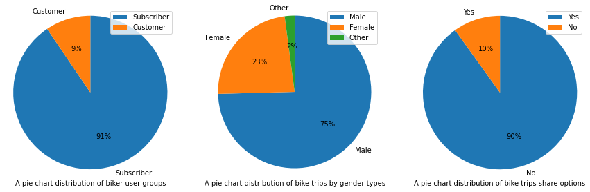

## Visualization 2 - Kde Plot Distribution of Hourly Start and End Trips

Secondly, it was important to also understand the distribution of start and end hour bike trips. It was observed that there are generally two peak times (morning and evening) for the bike trips on any average day as available in the dataset. This plot is illustrated in the sub-slide below

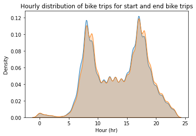

## Visualization 3 - Scatter and Heat Map Plot on Trip duration and Trip Distance

To understand the relationship between the bike trip duration times and distance covered based on values within the dataset as shown in the data plot below. A scatter plot and heatmap plot are used in convening this message as shown in the sub-slide below

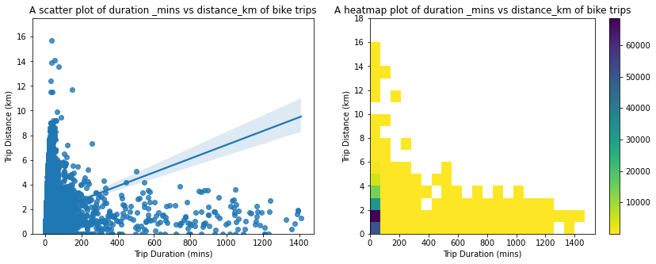

Using a clustered bar plot and a heatmap plot, I was able to understand the relationship pattern of trip start days of the week vs the age grade of bikers. It was important to understand which age group would tend to engage in bike trip and at which day of the week. These plots are illustrated in the sub-slide below

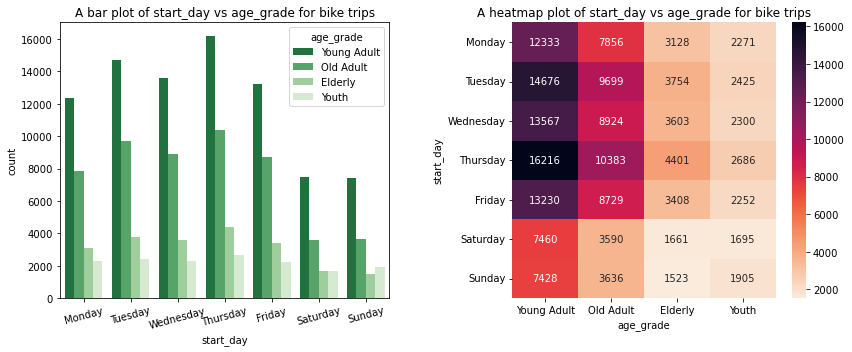

## Visualization 4 - Clustered Bar Chart and Heat Map Plot on Start Days and Start periods Relationship

Using a clustered bar plot and a heatmap plot, I was able to understand the categorical relationship pattern of trip start days of the week vs the trip start daily period of bikers. It was important to understand at which time period in a day bikers would tend to engage in bike trip and at which day of the week. These plots are illustrated in the sub-slide below

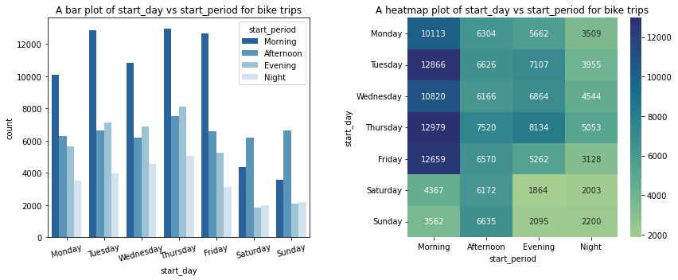

## Visualization 5 - Pointplot of Start period vs Trip Distance and Start Period vs Trip Duration

Lastly, I decided to illustrate the period of a day with the peak average trip duration and distance covered. This was capture using a two pointplots in the sub-slide below

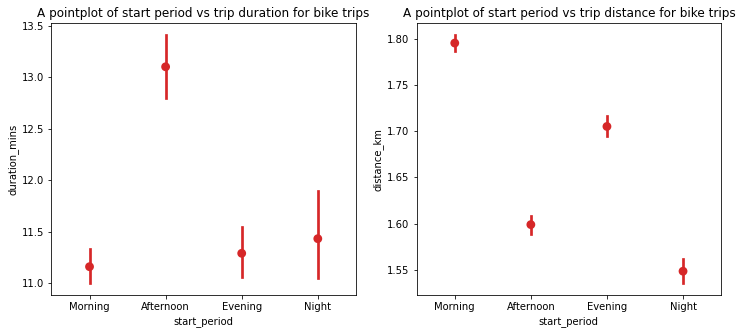